# Introduction to `ggplot2`

# Introduction

The goals of this lab are three-fold:

1. Familiarize ourselves with common visual summaries and the types of variables they represent
2. Learn the basics of data visualization in R
3. Create a `ggplot2` reference for use later in the semester.

We’ll begin by loading the appropriate package, `ggplot2` along with some of the data we will be using. First, create an R code chunk at the top of your lab and copy in the code below:

```r
## We load packages with the library() function
## This needs to be done every time you start a new R session
library(ggplot2)

# Make graphs less uggo for ggplot2
theme_set(theme_bw())

# Load majors data
majors <- read.csv("https://collinn.github.io/data/majors.csv")

# Get mpg dataset from ggplot2 package and modify variables
mpg <- as.data.frame(mpg)
mpg$cyl <- factor(mpg$cyl)
```

# Grammer of Graphics

We will do most of our plotting in R with the use of the `ggplot2`, a package that is intended to follow the [“grammar of graphics”](https://en.wikipedia.org/wiki/Wilkinson%27s_Grammar_of_Graphics) (hence the “gg”). This grammar provides a coherent philosophy of data visualization consisting of independent components that can be added together to build a plot. Every ggplot is made up of three components:

1. Data – the collected and observed variables we wish to visually represent
2. Aesthetics – A mapping between the data and visual properties, e.g., xy axes, color, etc.
3. Layers – How the observations in our data our rendered, e.g., scatterplot, box plot, etc.,

The first dataset we will use today is the `mpg` dataset included in `ggplot2`, including as observations EPA for a collection of 38 popular models.

```r
## head() is a function to show the first few rows of a data.frame
head(mpg)
```

```
##   manufacturer model displ year cyl      trans drv cty hwy fl   class
## 1         audi    a4   1.8 1999   4   auto(l5)   f  18  29  p compact
## 2         audi    a4   1.8 1999   4 manual(m5)   f  21  29  p compact
## 3         audi    a4   2.0 2008   4 manual(m6)   f  20  31  p compact
## 4         audi    a4   2.0 2008   4   auto(av)   f  21  30  p compact
## 5         audi    a4   2.8 1999   6   auto(l5)   f  16  26  p compact
## 6         audi    a4   2.8 1999   6 manual(m5)   f  18  26  p compact
```

Type `?mpg` in the console to see a complete description of the data and the variables used.

## Aesthetics

Every plot we make with `ggplot2` will begin with a call to the function `ggplot()` and an argument specifying the data wish to use. Without any additional information provided, all R does is reserve space and render a blank plot:

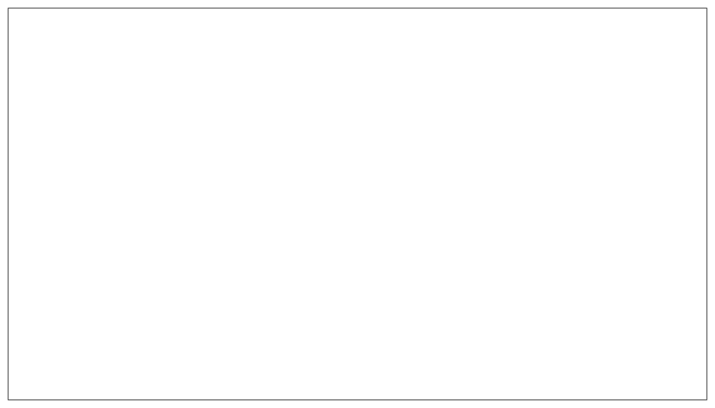

```r
ggplot(data = mpg)
```

We begin to add specific attributes to a plot with the use of *aesthetics*. Specifically within ggplot, the aesthetics are used to establish a relationship between *the variables in our data and the visual properties of the graph* such as the scale of the X and Y axes or the colors used. Notably, this does *not* include the specific values of the variable. In other words, a mapping of a height variable for students in STA 209 to an X axis may indicate the range our X axis should take (say, 58 inches to 76 inches), but it will not include any information about individual heights we have observed.

To illustrate, we begin by establishing a single axis, the X axis, mapped to the variable `cty` or city miles-per-gallon (noting again that `cty` is a variable included in `mpg`). Aesthetics in ggplot are added with the `aes()` function

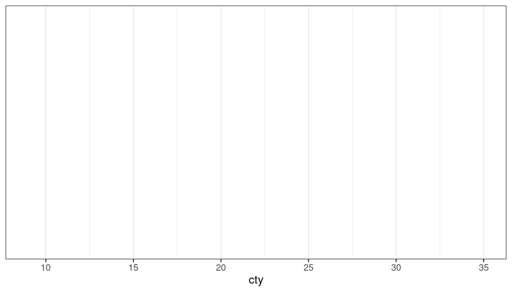

```r
ggplot(data = mpg, mapping = aes(x = cty))
```

Our plot still doesn’t have any data, but we can clearly see that one attribute (and its range) has been mapped from the `mpg` data.

The aesthetics we define will depend on a number of things including the type of plot used and the number of variables included. For example, a histogram only needs a single axis from the data (the Y axis being determined by frequency), whereas a scatterplot needs two axes, one of each of the variables. We can include additional aesthetics by placing them in the `aes()` function. (Note, we do not need to include `data =` and `mapping =` to call our function as they are implied by the order).

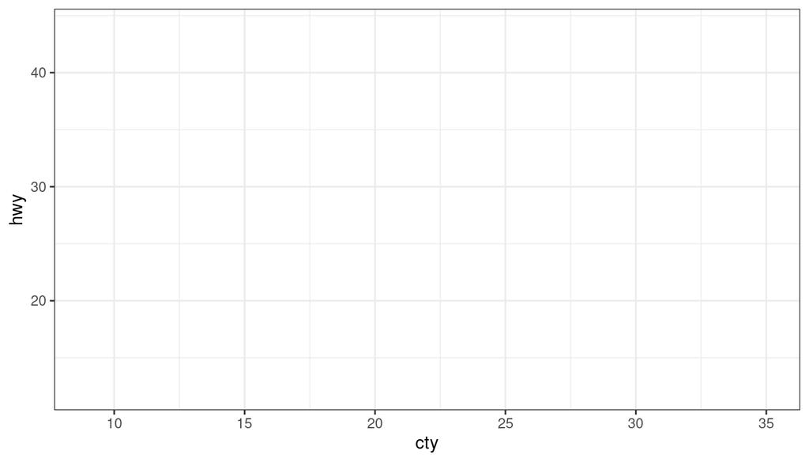

```r
ggplot(mpg, aes(x = cty, y = hwy))
```

Our ggplot now has two attributes, one for each `cty` and `hwy`, yet still no observed data.

## Layers

Once we have specified the data and aesthetics, we are ready to add *layers*, which are responsible for rendering the data in a plot. Layers are often referred to as “geoms” (for geometries) and can be added to an existing ggplot with `+`. There are a number of different geoms available, though for now we will add to our previous plot `geom_point()`, giving us a scatterplot

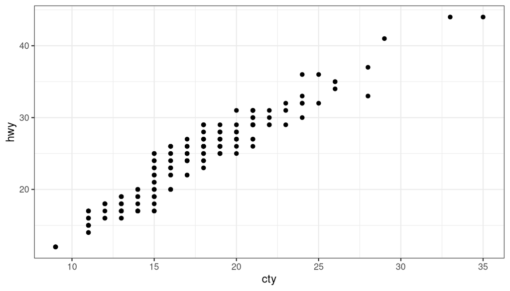

```r
ggplot(mpg, aes(x = cty, y = hwy)) +
  geom_point()
```

This is now the same plot as above, but with the individual observations now included.

Most layers that we might add in ggplot begin with `geom_` to help indicate that they can be thought of as the actual, geometric elements (lines, points, etc.,) that you will see on the plot. In addition to `geom_point()`, there are a few others that are worth being aware of:

- `geom_point` - scatter plots
- `geom_jitter` - scatter plot with “jittered” coordinates
- `geom_bar` - bar graph for categorical data
- `geom_smooth` - smoother for data
- `geom_boxplot` - box plot
- `geom_histogram` - histograms

None of these have to be memorized.

## Additional Aesthetics

While the x and y axes are the most common aesthetics, we can take advantage of the mapping between data and other visual properties. Here, we consider the `majors` dataset as an example, plotting the relationship between percentage male in a field against the median income for a bachelor’s degree:

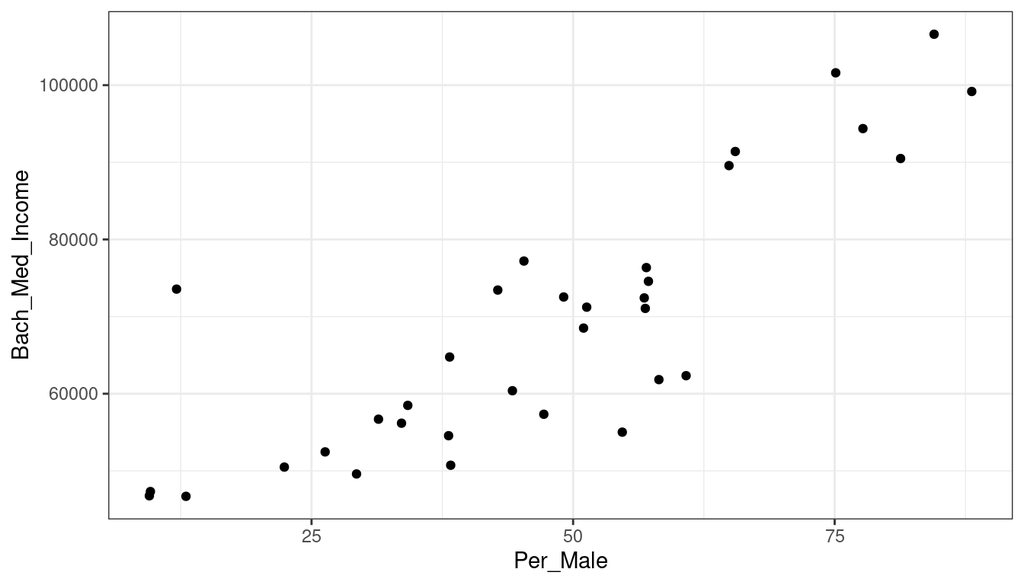

```r
## Per_Male = Percent Male
ggplot(majors, aes(x = Per_Male, y = Bach_Med_Income)) +
  geom_point()
```

By default, the first and second aesthetics are always `x` and `y`, so we do not need to specify them directly. We can also include a `color` aesthetic, allowing us to add another variable. In this case we add the variable `Category`, and represent it in the plot as a distinct color:

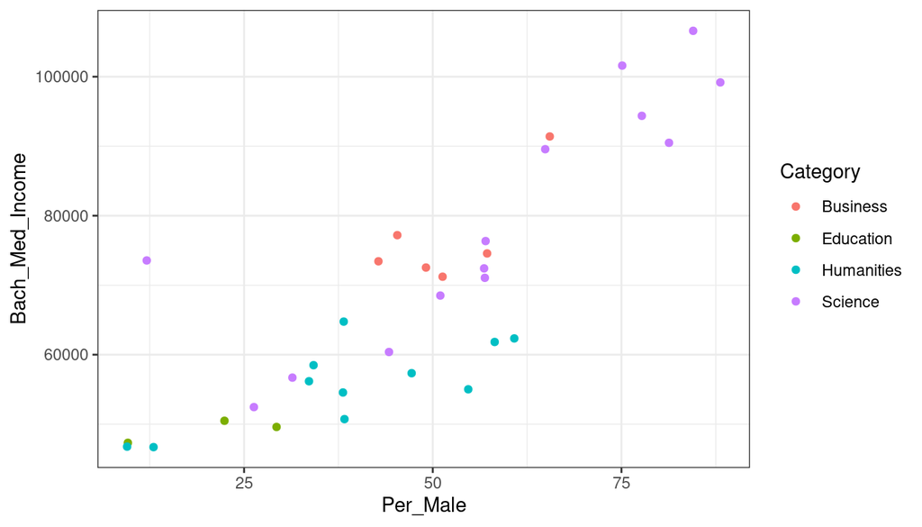

```r
## Adding color = Category
ggplot(majors, aes(Per_Male, Bach_Med_Income, color = Category)) +
  geom_point()
```

This is an example of a *multivariate* plot; it allows us to succinctly describe the relationship between 3 or more variables.

**Question 1:** Look at the two scatterplots above. From the first plot (without color), what can we see about the relationship between the variables? What information is added in the second plot, once we account for color?

This rest of this lab will be divided into four sections:

1. Univariate plots
2. Bivariate plots
3. Multivariate plots
4. Problem sets

At the very end of the lab is an additional section labeled as Examples, providing more or less a comprehensive collection of example plots and various arguments that can be added to a graphic. This is intended to serve as a reference for the rest of the semester.

# Types of Plots

## Univariate Plots

### Quantitative

For univariate quantitative variables, we will typically be interested in *histograms*, which show the relative frequency of numerical values over a particular domain. Consider the `majors` dataset, which contains a variable indicating the percentage within each college major that has obtained a PhD. As this is a single variable, we only need one aesthetic. Because we wish to generate a histogram, we will use the layer/geom associated with histograms:

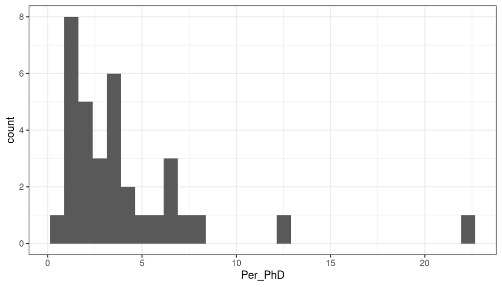

```r
## Per_PhD = percent with PhD
ggplot(majors, aes(x = Per_PhD)) +
  geom_histogram()
```

We can add additional arguments to layers that change their behavior. Here, I replicate the exact same histogram, this time modifying the fill and color variables inside of `geom_histogram()` to make it easier to see:

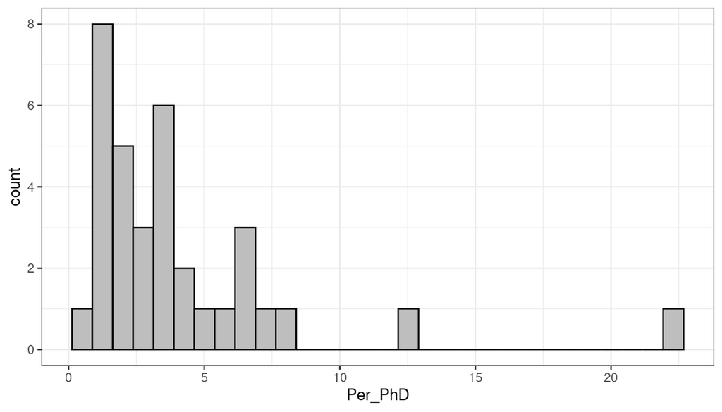

```r
## The 'color' is the outline of the bars, the `fill` is the shaded region
ggplot(majors, aes(x = Per_PhD)) +
  geom_histogram(color = 'black', fill = 'gray')
```

Histograms work through a process called *binning* in that it breaks a range of numbers (here, from 0 to about 25) into a number of equally sized “bins”. For each of our observations that fall into a bin, the associated bar increases by one. While there are few hard and fast rules associated with binning, it is helpful to try and modify the number of total bins to give us a better pictures of the distribution of the data. We do this with the `bins` argument in `geom_histogram()`

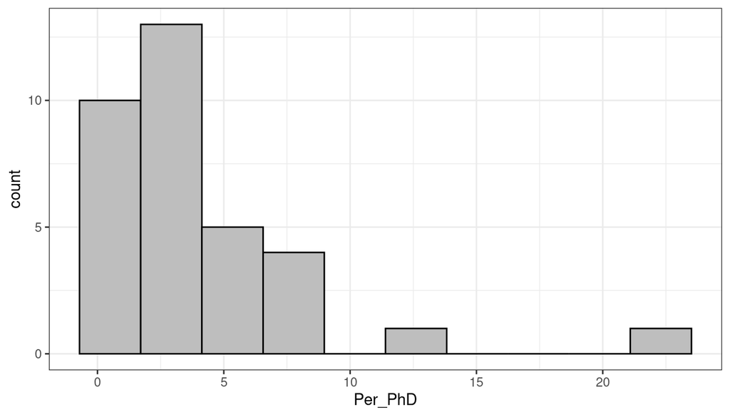

```r
ggplot(majors, aes(x = Per_PhD)) +
  geom_histogram(bins = 10, color = 'black', fill = 'gray')
```

**Question 2:** Using the example above, play around with various numbers. Between 10, 15, and 20 bins, which of these do you think best illustrates the data we have? Why do you come to that conclusion?

### Categorical

For categorical data, we are typically interested in either *counts* or *proportions*. These are represented with *bar plots*. Bar plots are similar to histograms in that they have the appearance of vertical bars, but it is important to recognize that they have different purposes and are associated with different types of data. Similar to histograms, however, they are added with an additional geom, `geom_bar()`

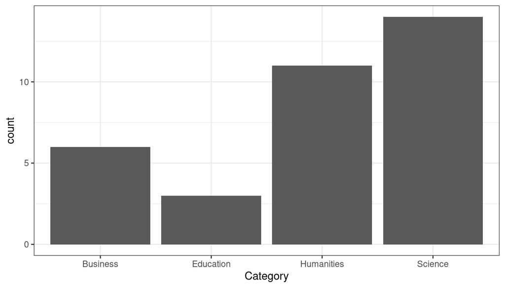

```r
ggplot(majors, aes(x = Category)) +
  geom_bar()
```

As you can see, the key difference between a bar plot and a histogram is the X axis; in the histogram, each bar or “bin” represents a range of numerical values while each bar in a bar plot is ever only associated with a single category.

It is also possible to use the y aesthetic instead. How do you think the plot generated from the code below differs from the plot above?

```r
ggplot(majors, aes(y = Category)) +
  geom_bar()
```

## Bivariate Plots

Bivariate plots, as the name suggests, are plots presenting the relationship with two variables. As before, the nature of these variables will dictate the type of plot used. For two variables, we have the following possible arrangements:

1. Two quantitative
2. One quantitative, one categorical
3. Two categorical

### Two Quantitative

The relationship between two quantitative variables is described with a *scatterplot*. We have seen this already in this lab, and it is added with the layer `geom_point()`

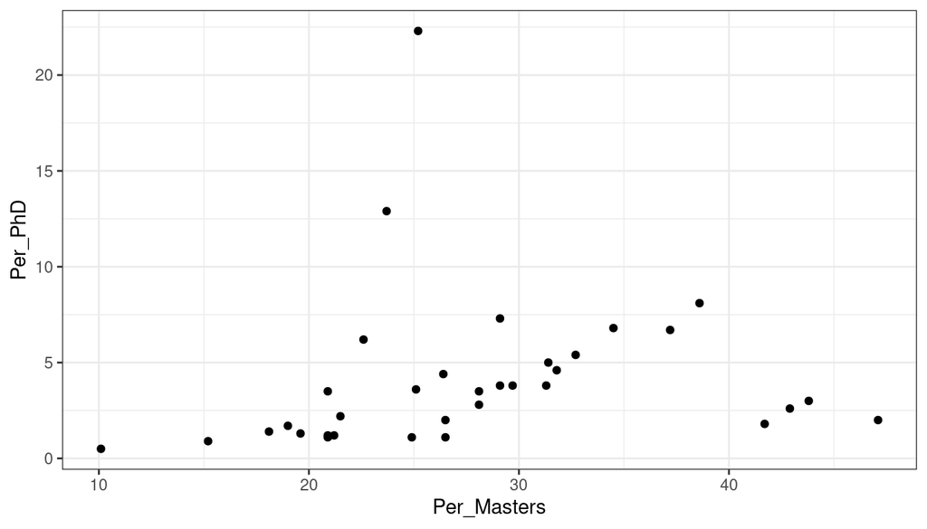

```r
## Per_ = percent
ggplot(majors, aes(Per_Masters, Per_PhD)) +
  geom_point()
```

Changing the order of the X and Y axis will not change the relationship between the variables, though depending on our goals it often makes sense to choose one arrangement over the other. Typically, we will want our *explanatory/independent* variable on the X axis, with the *response/dependent* variables on the Y axis.

### One Quantiative, One Categorical

In the case with a single quantitative variable, we were primarily interested in seeing the *distribution* of a single variable within our dataset. This idea extends naturally with the addition of a categorical variable, where now we are interested in seeing the distribution of a quantitative variable *within each category* of a categorical variable. This is done with a boxplot. A boxplot extends the idea of a numerical, five-figure summary into something visual, giving indications of the median, quantiles, and range of a quantitative variable. The typically are not used with a single quantitative variable alone, but there is nothing stopping us from doing so. They are created with the layer `geom_boxplot()`.

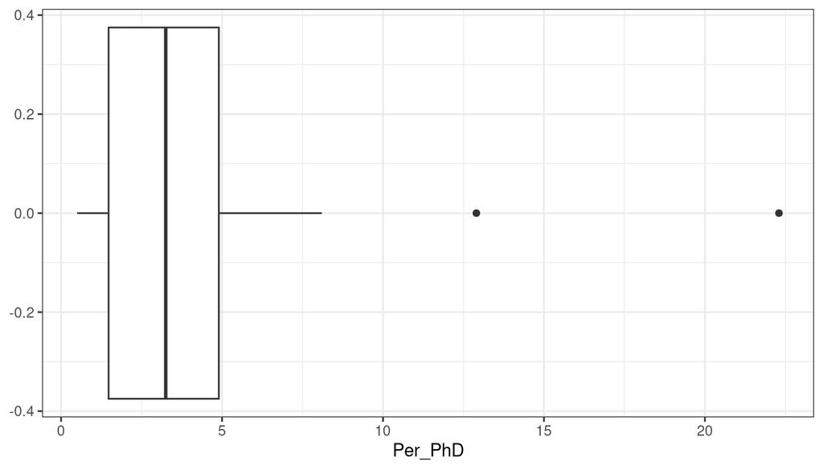

```r
## Only using a single quantitative variable
ggplot(majors, aes(x = Per_PhD)) +
  geom_boxplot()
```

More useful would be to see this distribution across a collection of categorical variables. As this involves mapping an additional variable to our plot, we indicate this addition by adding an additional aesthetic. It can be either X or Y, depending on how we would like our plot oriented

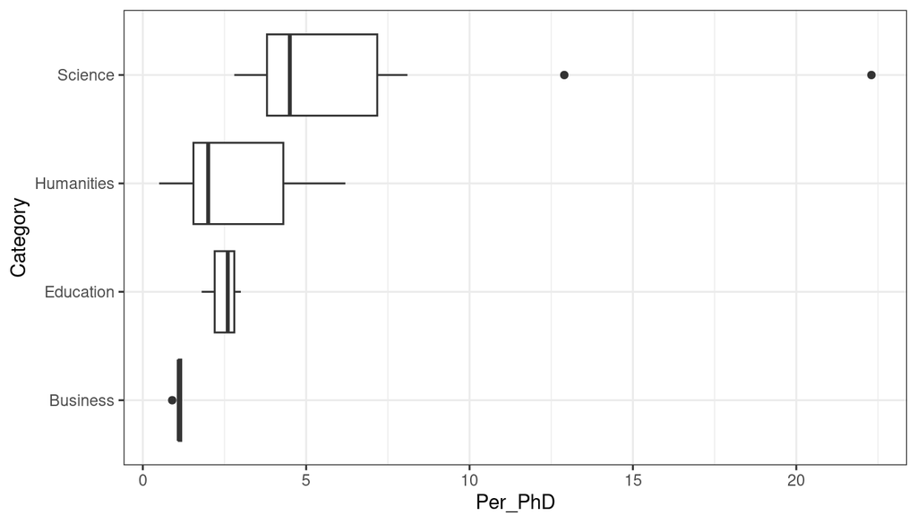

```r
## Quantiative and categorical variable
ggplot(majors, aes(x = Per_PhD, y = Category)) +
  geom_boxplot()
```

**Question 3:** How does the plot above help illustrate any *association* between the two variables, `Per_PhD` and `Category`? Summarize your findings in a 1-2 sentences.

### Two Categorical

To showcase situations with two categorical variables, we will use the `tips` dataset containing data on bill information for various meals at a restaurant. It may be worthwhile to take a minute or two to investigate the variables included in this data.

```r
tips <- read.csv("https://collinn.github.io/data/tips.csv")
head(tips)
```

```
##   total_bill  tip    sex smoker day   time size
## 1      16.99 1.01 Female     No Sun Dinner    2
## 2      10.34 1.66   Male     No Sun Dinner    3
## 3      21.01 3.50   Male     No Sun Dinner    3
## 4      23.68 3.31   Male     No Sun Dinner    2
## 5      24.59 3.61 Female     No Sun Dinner    4
## 6      25.29 4.71   Male     No Sun Dinner    4
```

The case for presenting two categorical variables in a plot is slightly more involved than were either of the other two bivariate scenarios, largely on account of the different types of relationships we may be interested in displaying. We don’t need to worry about this in too much detail, as it will be covered in greater depth later in the course. For now, we will simply investigate the two primary ways we may be interested in viewing these relationships.

First, let’s look at a univariate bar chart showing the frequency of meals that were served either for Lunch or Dinner with the variable `time`

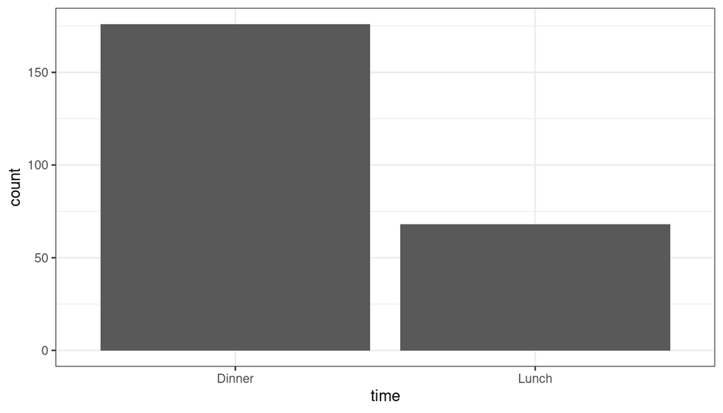

```r
ggplot(tips, aes(x = time)) + geom_bar()
```

Simple enough. If we wish to further break this down by an additional categorical variable, say, by smoking status, we can do so by adding an additional aesthetic `fill` (as in, “fill this box with color”) and assigning it the variable `smoker`:

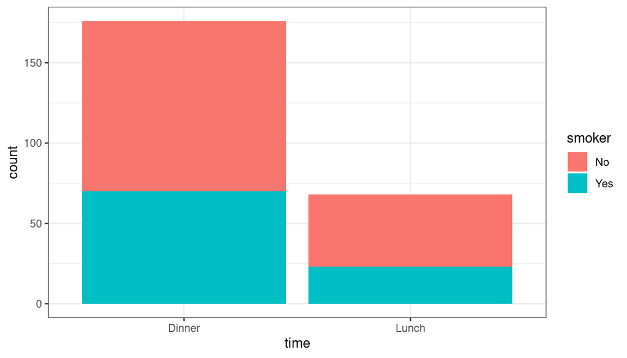

```r
ggplot(tips, aes(time, fill = smoker)) +
  geom_bar()
```

This plot shows us two things: we see absolute counts indicating that more people had dinner than lunch, and we see a breakdown of smoking status within each time. However, because the counts for dinner and lunch are so different, it can be difficult for us to assess how the *proportions* differ within each group. We can change this by specifying that that we want proportions instead of counts for our Y axis.

Similar to histograms, we can modify the layer itself by passing in additional arguments. In this case, we can use the `position` argument with the value “fill” to create a bar chart that shows us proportions (as in, “fill the vertical space in the graph”)

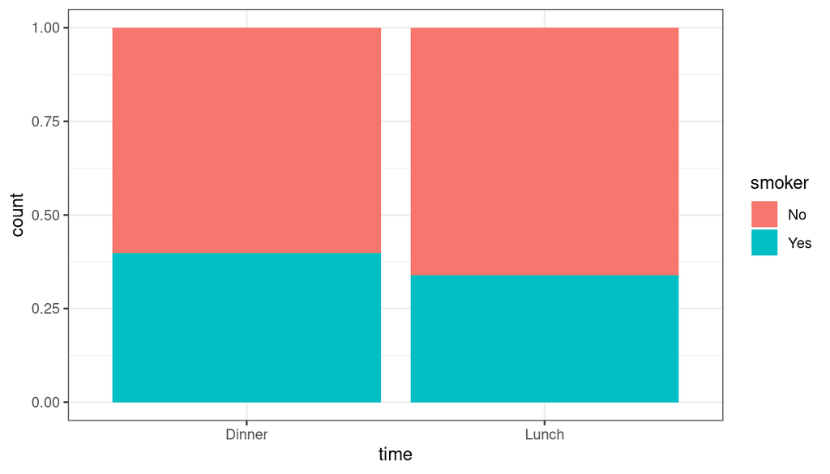

```r
## Note how the Y axis is now from 0 to 1
ggplot(tips, aes(time, fill = smoker)) +
  geom_bar(position = "fill")
```

Here, we can now see that a slightly higher proportion of dinner diners were smokers, compared with those at lunch. Does this appear to be a meaningful difference? It’s difficult to say. While visualizations can be informative and suggest various relationships, we should exercise caution in using them to draw stronger conclusions

The bar charts that we have seen until now are called “stacked” and “proportional” bar charts, respectively. Often however, we would prefer to see each of the partitioned categories on its own to compare, and we can do this by modifying the position argument in `geom_bar()`:

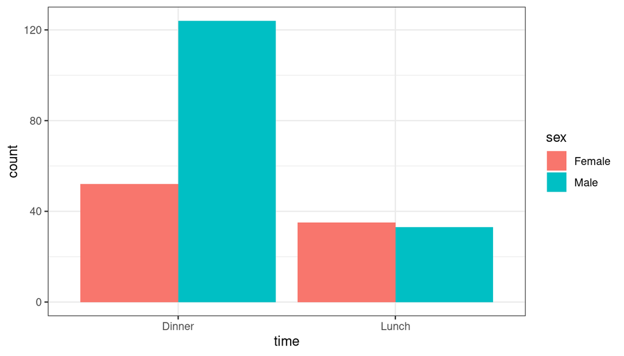

```r
ggplot(tips, aes(time, fill = sex)) +
  geom_bar(position = "dodge")
```

There are a number of variations on each of these plots that can be employed, some of which are included in the “Examples” section below. We will look at these in more detail a little later in the course.

## Multivariate Plots

Finally we come to multivariate plots which visually represent three or more variables in a dataset. While there are a wide variety of ways to do this (including with the use of size or shape), we will primarily limit ourselves to the use of two: color and faceting.

For our multivariate plots, we will be using a subset dataset containing attributes and outcomes for all primarily undergrad institutions in the US with at least 400 full-time students for the year 2019. Our particular subset will consists of college in Iowa and a few neighboring states

To load the data, simply copy and run the following:

```r
college <- read.csv("https://collinn.github.io/data/college2019.csv")
midwest <- subset(college, State %in% c("IA", "MN", "IL", "MO"))
```

### Color

As we have seen previously in this lab, the color aesthetic can be used to include an additional variable in our plots. How the color aesthetic maps will be dependent on the type of variable included. For example, consider a scatterplot demonstrating the relationship between the cost of tuition and the average faculty salary when a *categorical* variable is included in the color aesthetic.

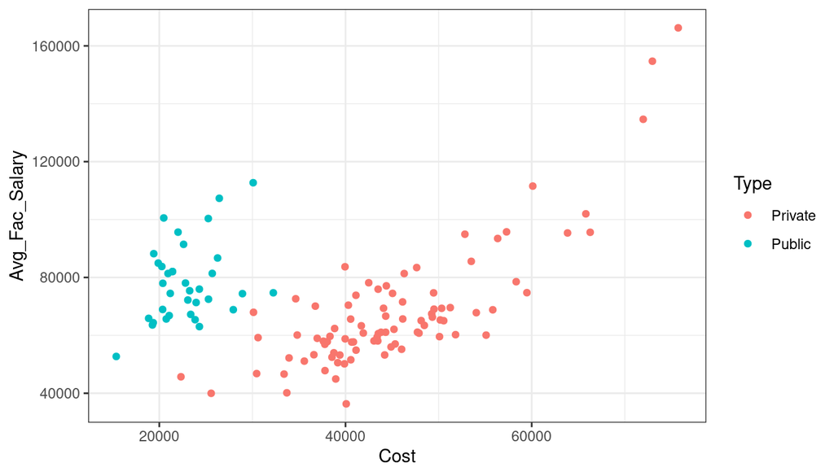

```r
ggplot(midwest, aes(Cost, Avg_Fac_Salary, color = Type)) +
  geom_point()
```

We see that a legend is created to the right of the plot, with distinct colors provided for each of the values within the category. Contrast this with the case in which a *quantitative* variable is included in the color aesthetic:

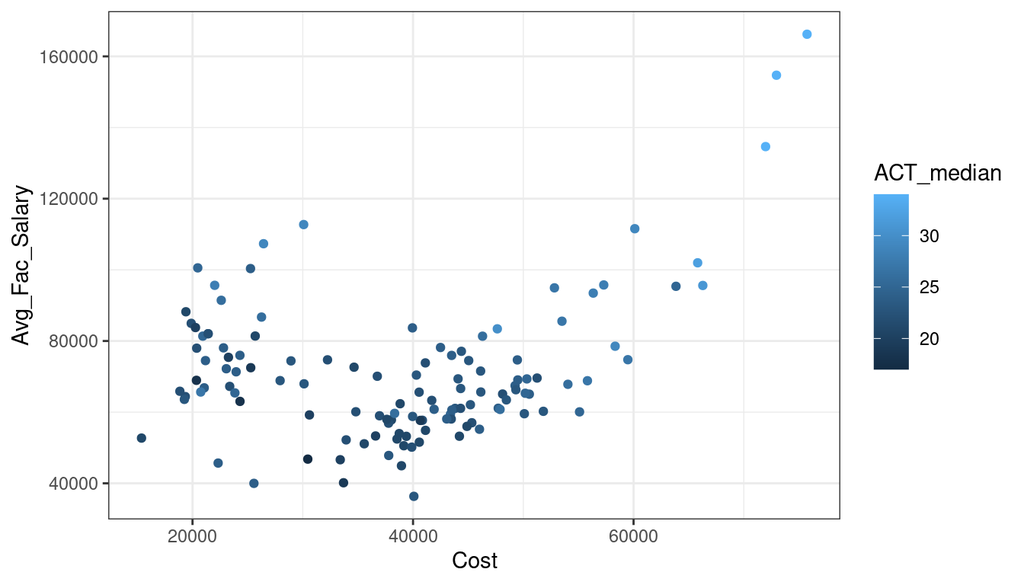

```r
ggplot(midwest, aes(Cost, Avg_Fac_Salary, color = ACT_median)) +
  geom_point()
```

How was this changed?

A quick note should be made regarding `color` and `fill` aesthetics. Objects that appear to be filled in will use `fill`, whereas `color` is typically one dimensional. The bar plots below demonstrate the difference:

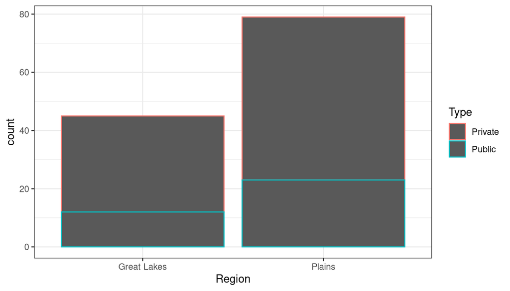

```r
## Using color
ggplot(midwest, aes(x = Region, color = Type)) +
  geom_bar()
```

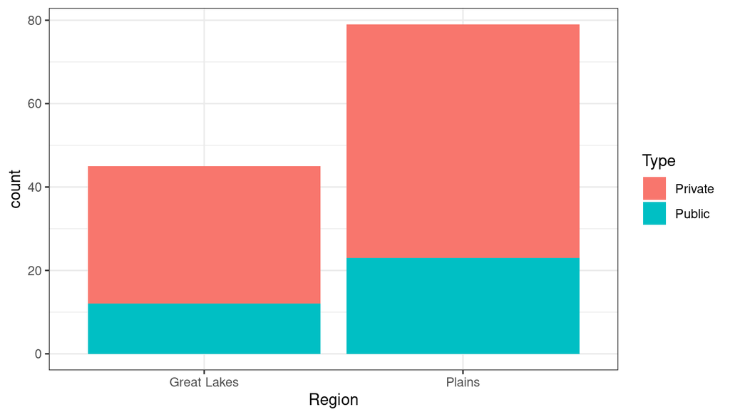

```r
## Using fill
ggplot(midwest, aes(x = Region, fill = Type)) +
  geom_bar()
```

Note that this color/fill distinction applies when using boxplots as well.

Visually inspecting a graph after making it is a quick and simple way to catch errors like this. A second (bonus) lab in ggplot will be made available to practice this and other beautification aspects for your ggplots.

### Faceting

While color allows us to add an additional variable within a single plot, *faceting* permits us to separate a plot into pieces based on the values of a category. This is helpful, for example, if we wish to see if various trends or relationships appear to be similar across groups.

Just as we used `+` to add a layer for our geoms, we use `+` again to add faceting. This syntax is a little bit different than we have seen generally, but it is of the form `facet_wrap(~variable)`, where `variable` is the name of the variable in the dataset we wish to facet. For example, to facet the above scatter plot relating cost to faculty salary, we can facet by State to view this for each of the different states

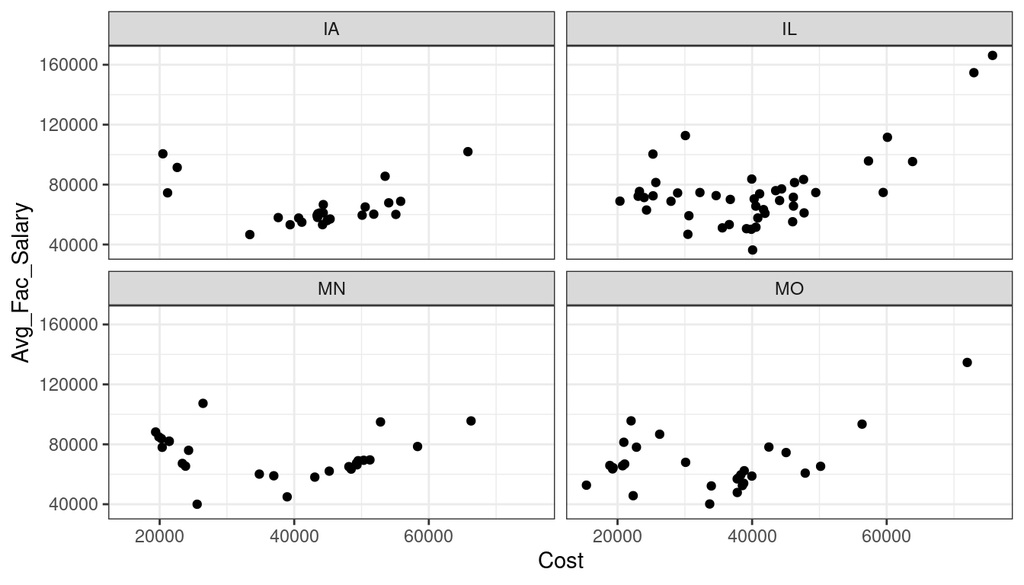

```r
ggplot(midwest, aes(Cost, Avg_Fac_Salary)) +
  geom_point() +
  facet_wrap(~State)
```

Of course, there is nothing from stopping us from limiting our multivariate plots to three variables; we can do four quite easily by adding a color aesthetic to our faceted plot:

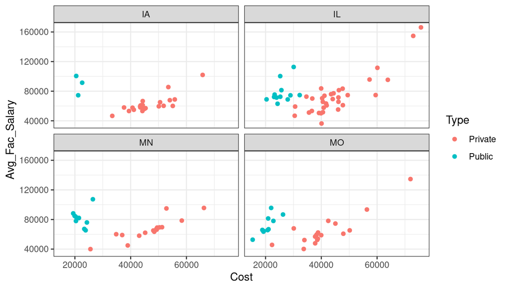

```r
ggplot(midwest, aes(Cost, Avg_Fac_Salary, color = Type)) +
  geom_point() +
  facet_wrap(~State)
```

As we can see, plots allow us to very quickly and concisely summarize the relationships between all different types of variables in our datasets. Throughout the semester we will continue to focus on creating and presenting effective visual data summaries which will involve both identifying the correct types of plots to create, given the variables we wish to summarize, as well as utilizing faceting and the various aesthetics to best capture the associations and relationships we wish to present.

# Problem Sets

## Part 1 - Univariate Plots

**Question 4:** The `class` variable in the `mpg` dataset details the “type” of car for each observation (pickup, SUV, etc.,). Create the appropriate graph to demonstrate this distribution of this variable and comment on which class appears to be the most frequent.

**Question 5:** The `cty` variable in the `mpg` dataset details the average fuel economy for the vehicle when driven in the city. Create the appropriate graph to represent this variable. Does this variable appear to be symmetric or skewed?

## Part 2 - Bivariate Plots

**Question 6:** Using the `mpg` dataset, we are interested in determining if either front wheel drive, rear wheel drive, or 4 wheel drive have better highway fuel economy (captured by the variables `drv` and `hwy`). Create the appropriate plot to show the distribution of fuel economy for each of these types of vehicles. Which appears to have the best fuel economy?

**Question 7:** In the `majors` dataset, the variable `Per_Masters` describes the percentage of the workforce within a particular field whose highest degree is a master’s degree. Create a graph to assess whether or not there appears to be a relationship between the percentage of individuals who hold a master’s degree and the percent that is unemployed. What do you find?

**Question 8:** Using the `mpg` dataset, create two plots to help answer:

1. Which class (`class`) of vehicle produces the largest number of 6 cylinder (`cyl`) vehicles
2. Which class of vehicle produces the greatest proportion of 6 cylinder vehicles

Note: The variable `cyl` here is treated as a categorical variable.

## Part 3 - Multivariate Plots

**Question 9:** Below is code that reads in `tips` data that are used in the Example section of this lab. First identify the four variables from the `tips` data that are used to make this plot and then write code to reproduce it. (This plot uses *faceting* which has examples at the end of the lab)

```r
tips <- read.csv("https://collinn.github.io/data/tips.csv")
```

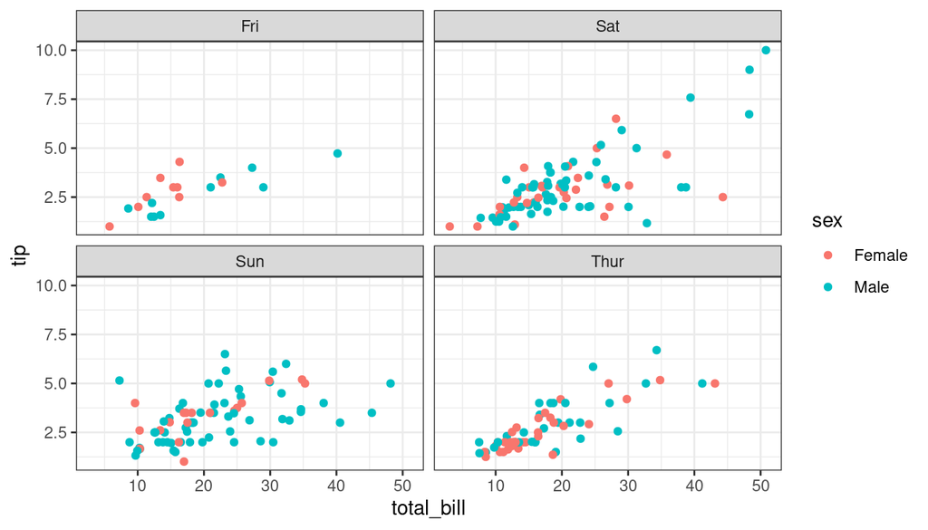

**Question 10:** Using the full version of the `college` dataset (provided again below), create two different plots box plots with a `fill` aesthetic to illustrate the relationship between region, type, and admission rate. Which of your plots would be more useful in answering the question, “Do private or public schools generally have a higher admission rate?”

```r
college <- read.csv("https://collinn.github.io/data/college2019.csv")
```

**Question 11:** The code below will load a data set containing 970 Hollywood films released between 2007 and 2011, then reduce these data to only include variables that could be known prior to a film’s opening weekend. The data are then simplified further to only include the four largest studios (Warner Bros, Fox, Paramount, and Universal) in the three most common genres (action, comedy, drama). You will use the resulting data for this question.

```r
## Read in data
movies <- read.csv("https://collinn.github.io/data/hollywood.csv")

## Simplify data
movies <- subset(movies, LeadStudio %in% c("Warner Bros", "Fox", "Paramount", "Universal") &
                               Genre %in% c("Action", "Comedy", "Drama"),
                       select = c("Movie", "LeadStudio", "Story", "Genre","Budget",
                                  "TheatersOpenWeek","Year","OpeningWeekend"))
```

Your goal in this question is to create a graphic that effectively differentiates movies with high revenue on opening weekend from those with low revenue on opening weekend (the variable `OpeningWeekend` records this revenue in millions of US dollars). In other words, using the plotting methods included in this lab, we want to create a visual summary of the data that answers the question: which trends or attributes seem to predict a film having low or high opening weekend revenue.

Your plot should include *at least* three variables from the dataset, either by including them in the axes, through color or fill, or through faceting. Finally, using the graph you have created, write 2-3 sentences explaining detailing what you have found.

# Examples

These examples will be done with the `tips` dataset, loaded in below:

```r
## Read in the "Tips" data
tips <- read.csv("https://collinn.github.io/data/tips.csv")
```

## Histograms

We can change the number of bins with `bins` argument. Feel free to play around with different numbers until you get what you want

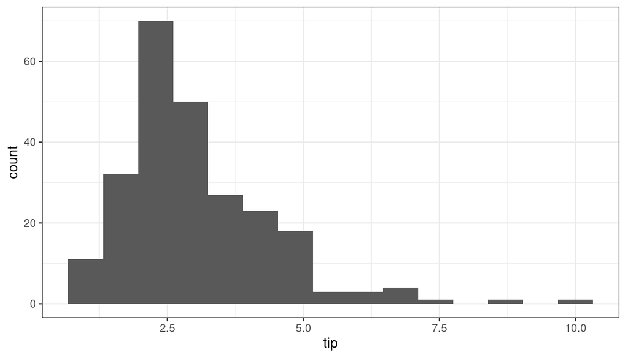

```r
ggplot(tips, aes(x = tip)) + geom_histogram(bins = 15)
```

I think the default colors here are incredibly ugly, so I usually add lines and a slightly less offensive color to histograms in one variable

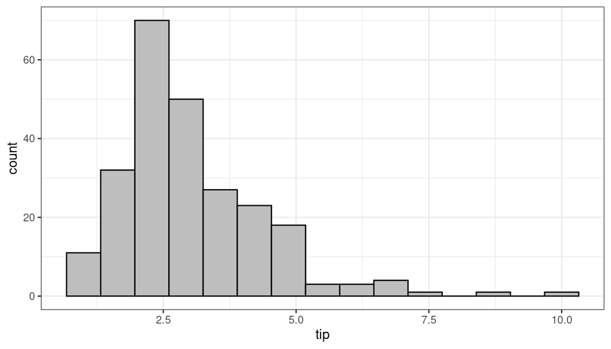

```r
ggplot(tips, aes(x = tip)) + geom_histogram(bins = 15, color = 'black', fill = 'gray')
```

## Boxplots

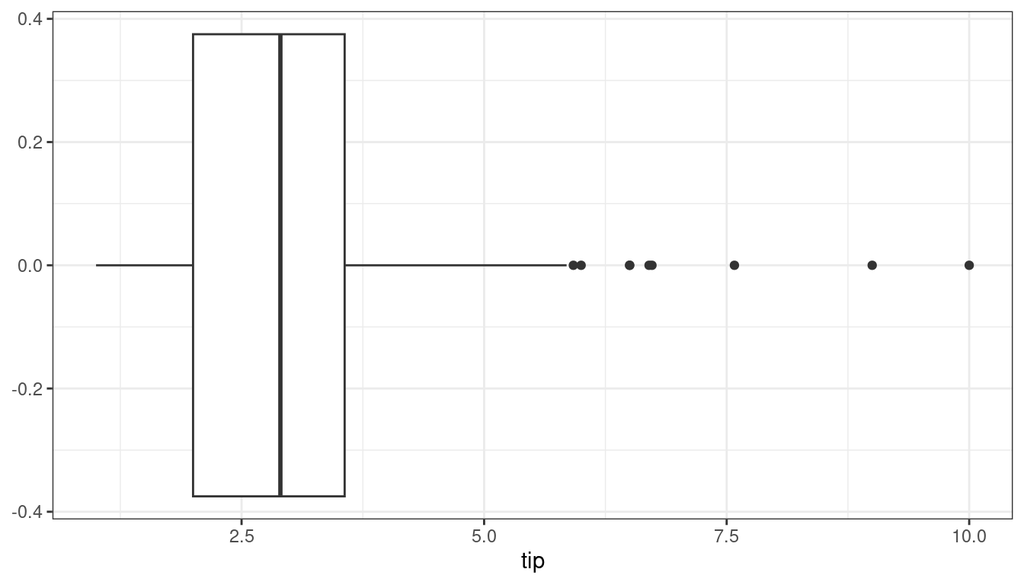

```r
ggplot(tips, aes(x = tip)) + geom_boxplot()
```

We can add groups by passing an extra categorical argument to `aes()`

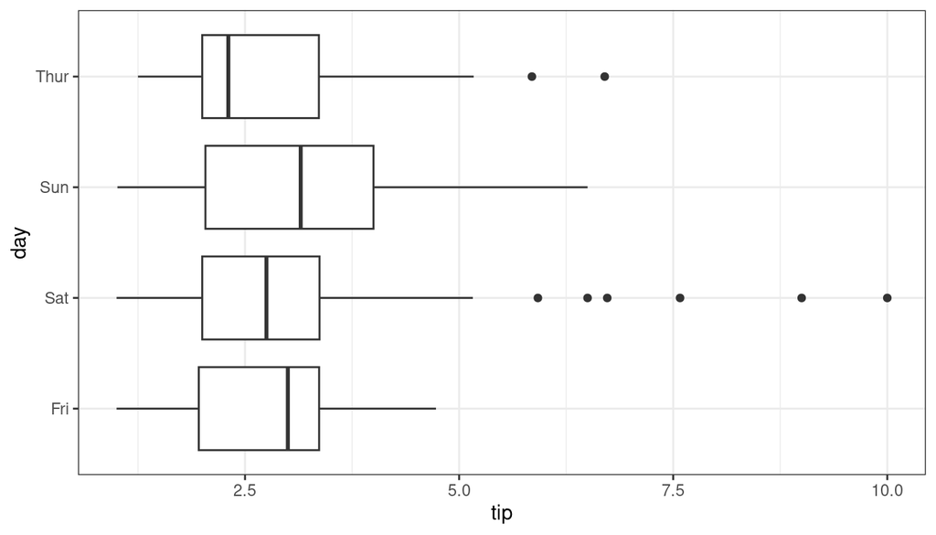

```r
ggplot(tips, aes(tip, y = day)) + geom_boxplot()
```

We can add more groups by including a color or fill aesthetic:

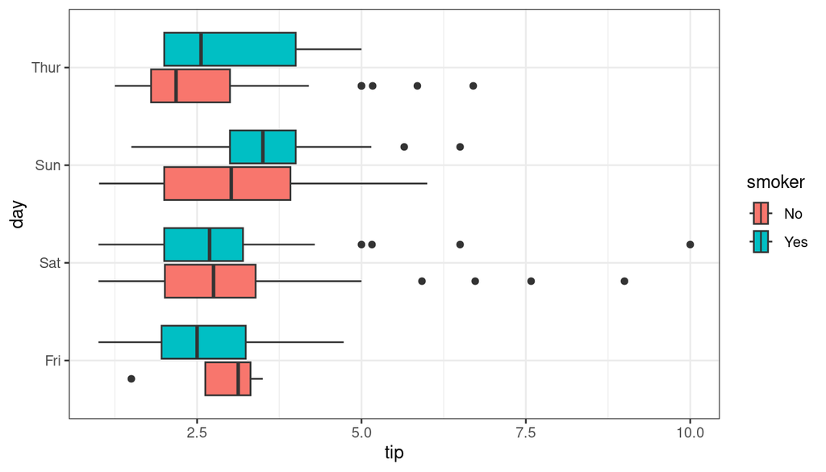

```r
ggplot(tips, aes(tip, y = day, fill = smoker)) + geom_boxplot()
```

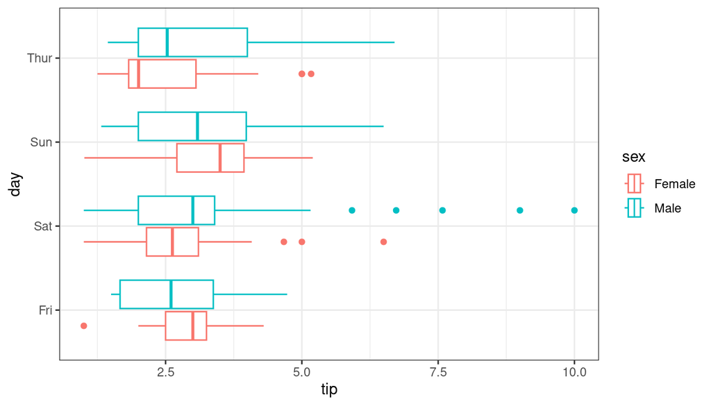

```r
ggplot(tips, aes(tip, y = day, color = sex)) + geom_boxplot()
```